# Data Science

## 2. Missing Values & Outliers handling

NOTE: missing values are already handled while merging different datasets in Task 1. So only outliers are handled below.

```python
subset_df=df[['Time','Duration_min', 'Exp_Years', 'src_elevation_ft', 'src_length_ft', 'src_width_ft', 'dest_elevation_ft', 'dest_length_ft', 'dest_width_ft']]
```

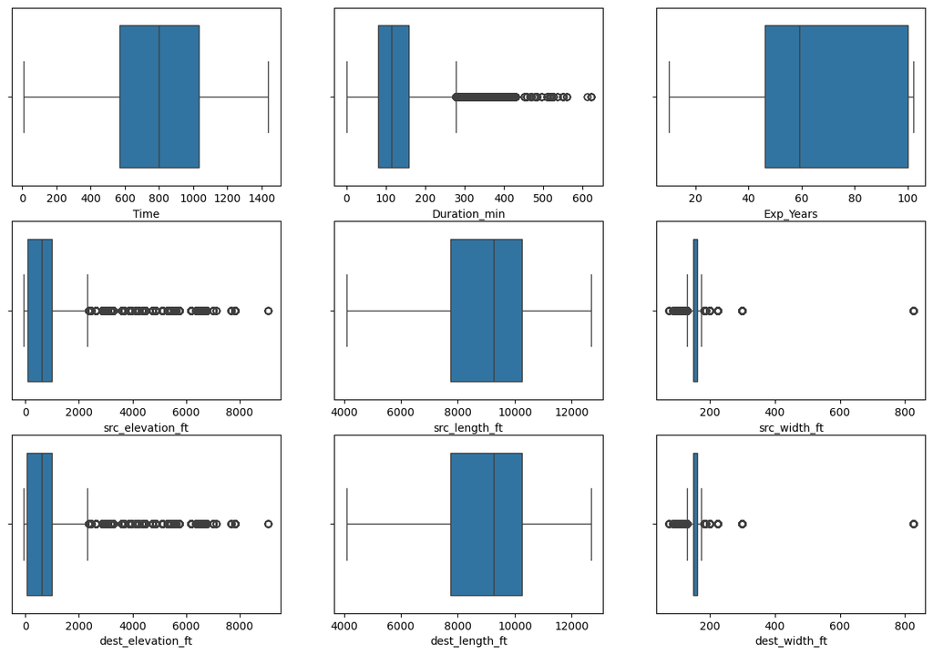

```python
#outliers detection using boxplot
plt.figure(figsize=(15,10))
for i in range(len(subset_df.columns)):
    plt.subplot(3,3,i+1)
    sns.boxplot(subset_df[subset_df.columns[i]],orient='h')
```

Looking at all boxplots , features 'Time' and 'Exp_Years' doesnt have outliers, but other features have some outliers which we will remove.

```python
outliers_elevation = df[(df['src_elevation_ft'] >= 8000) | (df['dest_elevation_ft'] >= 8000)].shape[0]
outliers_length = df[(df['src_length_ft'] <= 4100) | (df['dest_length_ft'] <= 4100)].shape[0]
outliers_width = df[(df['src_width_ft'] >= 300) | (df['dest_width_ft'] >= 300)].shape[0]
outliers_duration = df[df['Duration_min'] >= 600].shape[0]
print('Total Outliers')
print(f"Rows with elevation >= 8000ft: {outliers_elevation}")
print(f"Rows with runway length <= 4100ft: {outliers_length}")
print(f"Rows with runway width >= 300ft: {outliers_width}")
print(f"Rows with duration >= 600min: {outliers_duration}")
```

```
Total Outliers
Rows with elevation >= 8000ft: 34
Rows with runway length <= 4100ft: 97
Rows with runway width >= 300ft: 786
Rows with duration >= 600min: 17
```

```python
# removing outliers based on above conditions
df = df[(df['src_elevation_ft'] < 8000) & (df['dest_elevation_ft'] < 8000)]
df = df[(df['src_length_ft'] > 4100) & (df['dest_length_ft'] > 4100)]
df = df[(df['src_width_ft'] < 300) & (df['dest_width_ft'] < 300)]
df = df[df['Duration_min'] < 600]
df.reset_index(drop=True, inplace=True)
```

```python
df.shape
```

```
(254929, 28)
```

## 3. Data visualization and insights

### 3.1 Delay by Airlines

```python
df.head(2)
```

|  | Airline | Flight | AirportFrom | AirportTo | DayOfWeek | Time | Duration_min | Delay | Airline_name | Exp_Years | ... | src_closed | src_surface | dest_type | dest_elevation_ft | dest_num_runways | dest_length_ft | dest_width_ft | dest_lighted | dest_closed | dest_surface |
| --- | --- | --- | --- | --- | --- | --- | --- | --- | --- | --- | --- | --- | --- | --- | --- | --- | --- | --- | --- | --- | --- |
| 0 | AA | 2400 | LAX | DFW | 3 | 20 | 165 | 1 | American Airlines | 100.0 | ... | 0.0 | CON | large_airport | 607.0 | 7.0 | 11486.142857 | 171.428571 | 1.0 | 0.0 | CON |
| 1 | AA | 2466 | SFO | DFW | 3 | 20 | 195 | 1 | American Airlines | 100.0 | ... | 0.0 | ASP | large_airport | 607.0 | 7.0 | 11486.142857 | 171.428571 | 1.0 | 0.0 | CON |

2 rows × 28 columns

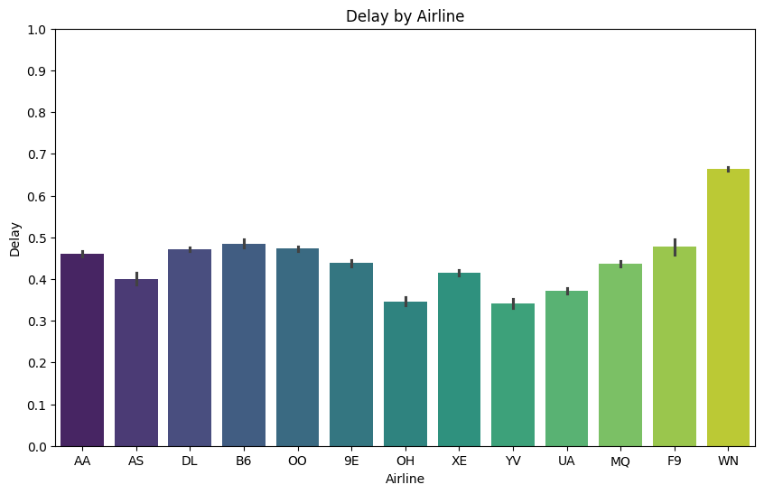

```python
plt.figure(figsize=(10, 6))
plt.title('Delay by Airline')
plt.ylim(0, 1)
plt.yticks(np.arange(0, 1.1, 0.1))
sns.barplot(data=df,x='Airline',y='Delay',palette='viridis')
plt.show()
```

According to barplot, approximately 70% of Southwest Airlines flights are delayed

### 3.2 Daywise Flight delays

```python
(df['DayOfWeek'][df['Delay']==1]).value_counts() / df['DayOfWeek'].value_counts()
```

```
1    0.500055
2    0.493252
3    0.510572
4    0.491200
5    0.498920
6    0.433584
7    0.485990
Name: DayOfWeek, dtype: float64
```

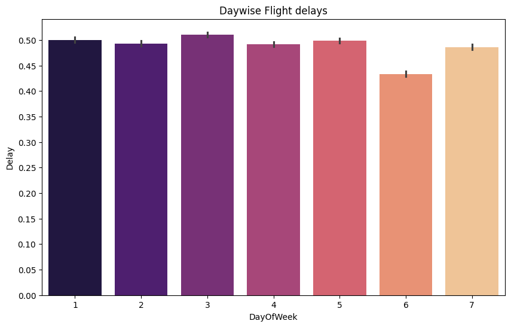

```python
plt.figure(figsize=(10, 6))
plt.title('Daywise Flight delays')
plt.yticks(np.arange(0, 1.1, 0.05))
sns.barplot(data=df,x='DayOfWeek',y='Delay',palette='magma')
plt.show()
```

We can see from graph that Day 6 (Saturday) has the lowest delays. Hence Saturday is the safest for travel.

### 3.3 Airlines recommendation for short, medium and long-distance travel

NOTE: Assuming -  
Short: < 90 minutes(less than 1.5 hrs) , Medium: 90-180 minutes(1.5-3 hrs) , Long: > 180 minutes(more than 3 hrs)

```python
df.loc[df['Duration_min']<90, 'Distance_type'] = 'Short'
df.loc[(df['Duration_min']>=90) & (df['Duration_min']<180), 'Distance_type'] = 'Medium'
df.loc[df['Duration_min']>=180, 'Distance_type'] = 'Long'
```

```python
# df['Distance_type']=pd.cut(df['Duration_min'],bins=[-np.inf,89,180,np.inf],labels=['Short','Medium','Long'])
```

```python
df['Distance_type']
```

```
0         Medium
1           Long
2           Long
3           Long
4           Long
           ...
254924      Long
254925      Long
254926      Long
254927      Long
254928      Long
Name: Distance_type, Length: 254929, dtype: object
```

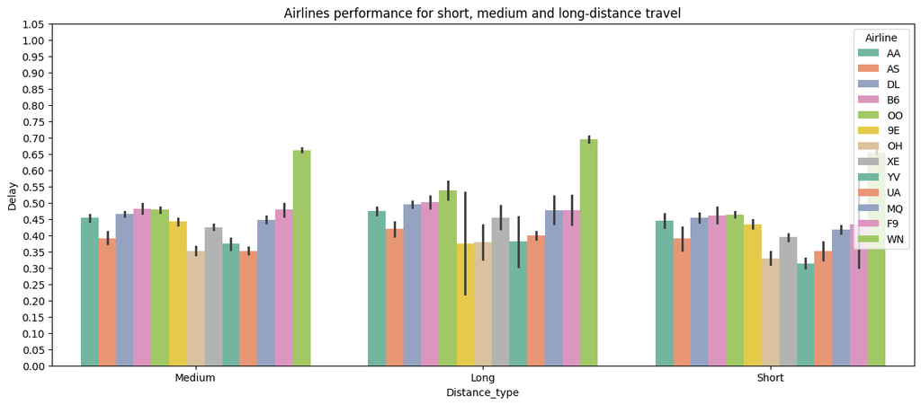

```python
plt.figure(figsize=(15, 6))
plt.title('Airlines performance for short, medium and long-distance travel')
plt.ylim(0, 1)
plt.yticks(np.arange(0, 1.1, 0.05))
sns.barplot(data=df,x='Distance_type',y='Delay',hue='Airline',palette='Set2')
plt.show()
```

```python
print(df['Airline_name'][df['Airline']=='YV'][:1])
print(df['Airline_name'][df['Airline']=='UA'][:1])
print(df['Airline_name'][df['Airline']=='9E'][:1])
```

```
50    Mesa Airlines
Name: Airline_name, dtype: object
51    United Airlines
Name: Airline_name, dtype: object
22    Endeavor Air
Name: Airline_name, dtype: object
```

As per graph we can say that Airlines recommendation is YV (Mesa Airlines) for short distance , UA (United Airlines) for medium distance travel and 9E (Endeavor Air) for long-distance travel.